# Crayon - Final PPT

```python
import pandas as pd
import numpy as np
from sklearn import ensemble, preprocessing
import xgboost as xgb
import matplotlib.pyplot as plt
import seaborn as sns
import pylab
```

```python
import os
os.getcwd()
os.chdir(r'G:\Project_Py')
```

```python
data = pd.read_csv(r'data.csv',sep = ';')
data.shape
```

```
(1436, 10)
```

```python
data.dtypes
```

```
Y              int64
Feature 1      int64
Feature 2      int64
Feature 3    float64
Feature 4      int64
Feature 5      int64
Feature 6      int64
Feature 7      int64
Feature 8      int64
Feature 9      int64
dtype: object
```

```python
data.head()
```

|  | Y | Feature 1 | Feature 2 | Feature 3 | Feature 4 | Feature 5 | Feature 6 | Feature 7 | Feature 8 | Feature 9 |
| --- | --- | --- | --- | --- | --- | --- | --- | --- | --- | --- |
| 0 | 13500 | 23 | 46986 | 1.0 | 90 | 1 | 0 | 2000 | 3 | 1165 |
| 1 | 13750 | 23 | 72937 | 1.0 | 90 | 1 | 0 | 2000 | 3 | 1165 |
| 2 | 13950 | 24 | 41711 | 1.0 | 90 | 1 | 0 | 2000 | 3 | 1165 |
| 3 | 14950 | 26 | 48000 | 1.0 | 90 | 0 | 0 | 2000 | 3 | 1165 |
| 4 | 13750 | 30 | 38500 | 1.0 | 90 | 0 | 0 | 2000 | 3 | 1170 |

```python
data.describe()
```

|  | Y | Feature 1 | Feature 2 | Feature 3 | Feature 4 | Feature 5 | Feature 6 | Feature 7 | Feature 8 | Feature 9 |
| --- | --- | --- | --- | --- | --- | --- | --- | --- | --- | --- |
| count | 1436.000000 | 1436.000000 | 1436.000000 | 414.000000 | 1436.000000 | 1436.000000 | 1436.000000 | 1436.000000 | 1436.000000 | 1436.00000 |
| mean | 10730.824513 | 55.947075 | 68533.259749 | 0.173913 | 101.502089 | 0.674791 | 0.055710 | 1566.827994 | 4.033426 | 1072.45961 |
| std | 3626.964585 | 18.599988 | 37506.448872 | 0.379493 | 14.981080 | 0.468616 | 0.229441 | 187.182436 | 0.952677 | 52.64112 |
| min | 4350.000000 | 1.000000 | 1.000000 | 0.000000 | 69.000000 | 0.000000 | 0.000000 | 1300.000000 | 2.000000 | 1000.00000 |
| 25% | 8450.000000 | 44.000000 | 43000.000000 | 0.000000 | 90.000000 | 0.000000 | 0.000000 | 1400.000000 | 3.000000 | 1040.00000 |
| 50% | 9900.000000 | 61.000000 | 63389.500000 | 0.000000 | 110.000000 | 1.000000 | 0.000000 | 1600.000000 | 4.000000 | 1070.00000 |
| 75% | 11950.000000 | 70.000000 | 87020.750000 | 0.000000 | 110.000000 | 1.000000 | 0.000000 | 1600.000000 | 5.000000 | 1085.00000 |
| max | 32500.000000 | 80.000000 | 243000.000000 | 1.000000 | 192.000000 | 1.000000 | 1.000000 | 2000.000000 | 5.000000 | 1615.00000 |

## Analyze Y Variable

```python
#descriptive statistics summary
data['Y'].describe()
```

```
count     1436.000000
mean     10730.824513
std       3626.964585
min       4350.000000
25%       8450.000000
50%       9900.000000
75%      11950.000000
max      32500.000000
Name: Y, dtype: float64
```

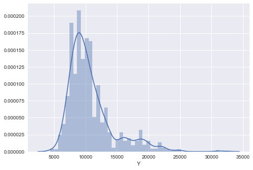

```python
#histogram
sns.distplot(data['Y']);
plt.show()
```

Deviate from the normal distribution. Have appreciable positive skewness. Show peakedness.

```python
#skewness and kurtosis
print("Skewness: %f" % data['Y'].skew()) ## right skew
print("Kurtosis: %f" % data['Y'].kurt()) ## positive skewed within real range
```

```
Skewness: 1.703885
Kurtosis: 3.737781
```

### Missing Value

Important questions when thinking about missing data:

How prevalent is the missing data?I Is missing data random or does it have a pattern?

```python
#missing data
total = data.isnull().sum().sort_values(ascending=False)
percent = (data.isnull().sum()/data.isnull().count()).sort_values(ascending=False)
missing_data = pd.concat([total, percent], axis=1, keys=['Total', 'Percent'])
missing_data.head(20)
```

|  | Total | Percent |
| --- | --- | --- |
| Feature 3 | 1022 | 0.711699 |
| Feature 9 | 0 | 0.000000 |
| Feature 8 | 0 | 0.000000 |
| Feature 7 | 0 | 0.000000 |
| Feature 6 | 0 | 0.000000 |
| Feature 5 | 0 | 0.000000 |
| Feature 4 | 0 | 0.000000 |
| Feature 2 | 0 | 0.000000 |
| Feature 1 | 0 | 0.000000 |
| Y | 0 | 0.000000 |

Feature 3 has more than 70% missing data, we shall Delete Feature 3

# Exploratory data Analysis

```python
likely_cat = {}
for var in data.columns:
    likely_cat[var] = 1.*data[var].nunique()/data[var].count() < 0.03 #or some other threshold
```

```python
likely_cat
```

```
{'Feature 1': False,
 'Feature 2': False,
 'Feature 3': True,
 'Feature 4': True,
 'Feature 5': True,
 'Feature 6': True,
 'Feature 7': True,
 'Feature 8': True,
 'Feature 9': False,
 'Y': False}
```

```python
cols = ['Feature 4', 'Feature 5', 'Feature 6',
       'Feature 7', 'Feature 8', 'Feature 9']
likely_uniq = {}
for var in cols:
    likely_uniq[var] = data[var].unique()
```

```python
likely_uniq
```

```
{'Feature 4': array([ 90, 192,  69, 110,  97,  71, 116,  98,  86,  72, 107,  73], dtype=int64),
 'Feature 5': array([1, 0], dtype=int64),
 'Feature 6': array([0, 1], dtype=int64),
 'Feature 7': array([2000, 1800, 1900, 1600, 1400, 1598, 1995, 1398, 1300, 1587, 1975,
        1332], dtype=int64),
 'Feature 8': array([3, 5, 4, 2], dtype=int64),
 'Feature 9': array([1165, 1170, 1245, 1185, 1105, 1065, 1120, 1100, 1255, 1270, 1110,
        1195, 1180, 1075, 1130, 1275, 1060, 1115, 1265, 1260, 1125, 1155,
        1045, 1480, 1320, 1280, 1135, 1090, 1150, 1085, 1160, 1205, 1084,
        1140, 1095, 1025, 1119, 1080, 1121, 1615, 1067, 1040, 1030, 1055,
        1050, 1103, 1070, 1035, 1015, 1000, 1078, 1079, 1109, 1020, 1010,
        1114, 1172, 1094, 1083], dtype=int64)}
```

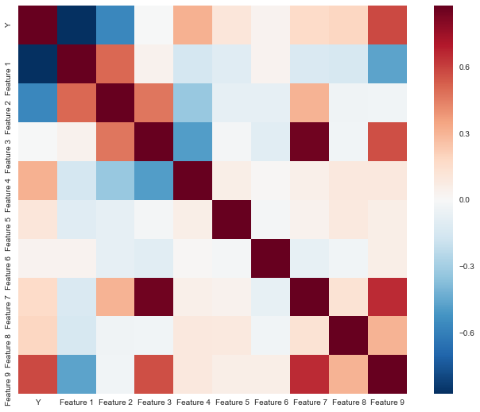

```python
#correlation matrix
corrmat = data.corr()
corrmat.style.background_gradient()
corrmat.style.background_gradient().set_precision(2)

f, ax = plt.subplots(figsize=(12, 9))
sns.heatmap(corrmat, vmax=.8, square=True)
plt.show()
```

Feature 3 and Feature 6 shows less corr with Y variable

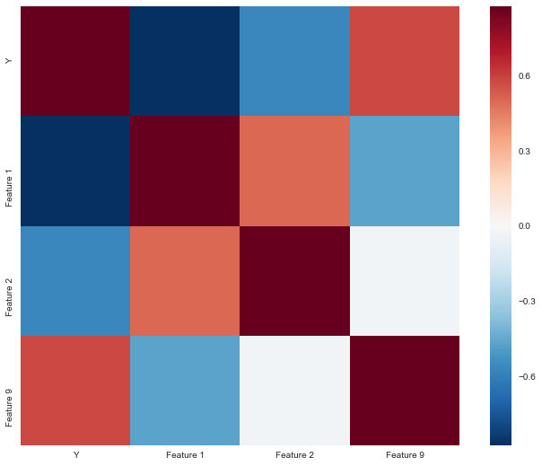

```python
#correlation matrix for continuous vars
colscorr = ['Y', 'Feature 1', 'Feature 2', 'Feature 9']
corrmat = data[colscorr].corr()
f, ax = plt.subplots(figsize=(12, 9))
sns.heatmap(corrmat, vmax=.8, square=True)
plt.show()
```

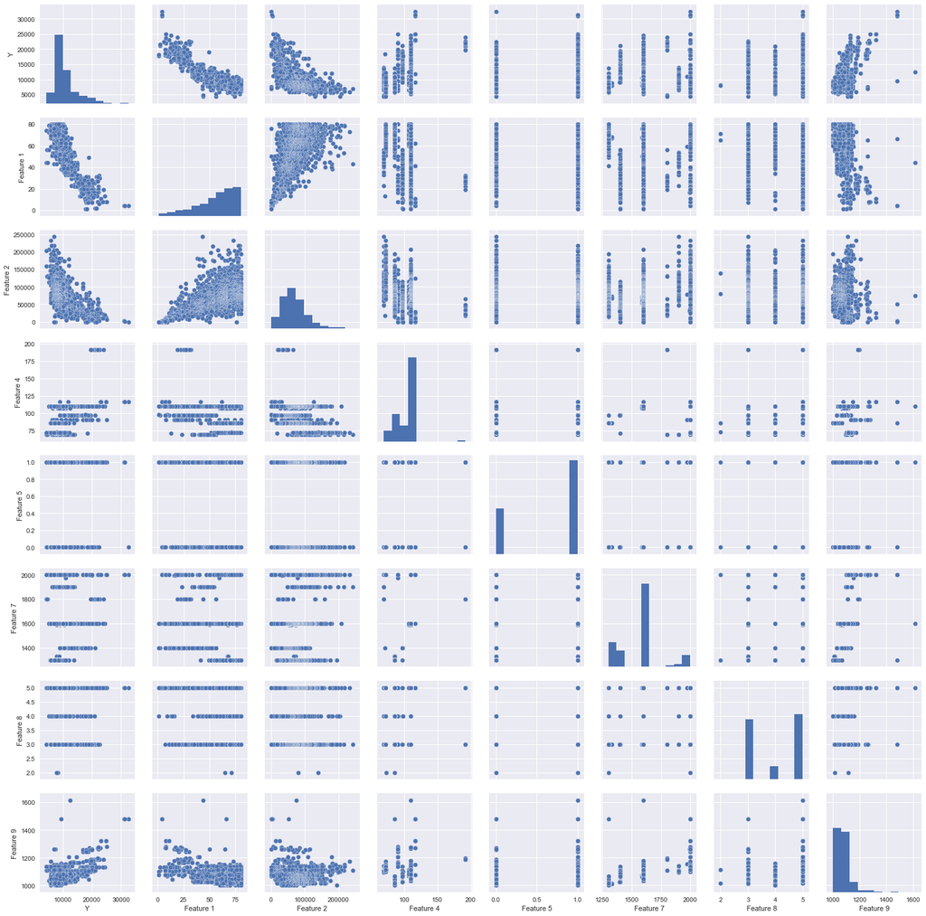

```python
#scatterplot ignoring fet 3 and fet 6
sns.set()
cols = ['Y', 'Feature 1', 'Feature 2','Feature 4', 'Feature 5', 'Feature 7', 'Feature 8', 'Feature 9']
sns.pairplot(data[cols], size = 2.5)
plt.show();
```

# Relationship with continuous and Category variables

## Relationship with categorical features with Y

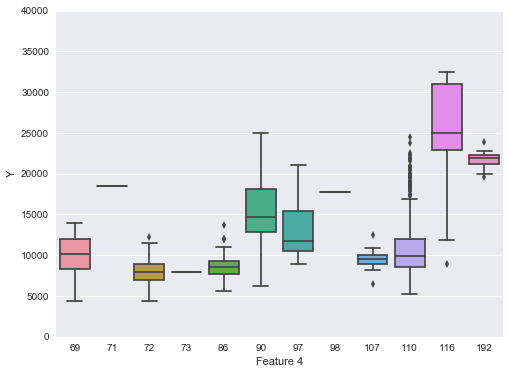

```python
#box plot
var = 'Feature 4'
data1 = pd.concat([data['Y'], data[var]], axis=1)
f, ax = plt.subplots(figsize=(8, 6))
fig = sns.boxplot(x=var, y="Y", data=data1)
fig.axis(ymin=0, ymax=40000);
plt.show()
```

# we reduce the classes by grouping same median value in same classes

1: 69, 72,73,86,107,110  
2: 71,98,192  
3: 90,97  
4: 116

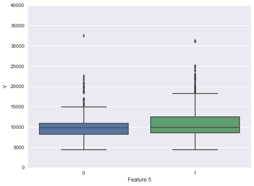

```python
#box plot
var = 'Feature 5'
data1 = pd.concat([data['Y'], data[var]], axis=1)
f, ax = plt.subplots(figsize=(8, 6))
fig = sns.boxplot(x=var, y="Y", data=data1)
fig.axis(ymin=0, ymax=40000);
plt.show()
```

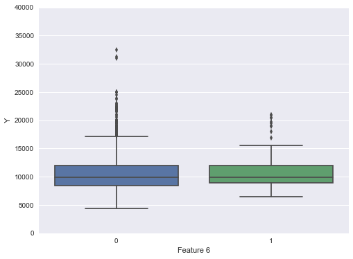

```python
#box plot
var = 'Feature 6'
data1 = pd.concat([data['Y'], data[var]], axis=1)
f, ax = plt.subplots(figsize=(8, 6))
fig = sns.boxplot(x=var, y="Y", data=data1)
fig.axis(ymin=0, ymax=40000);
plt.show()
```

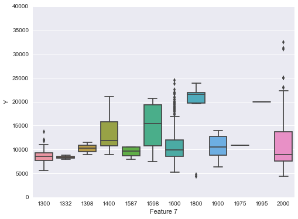

```python
#box plot
var = 'Feature 7'
data1 = pd.concat([data['Y'], data[var]], axis=1)
f, ax = plt.subplots(figsize=(8, 6))
fig = sns.boxplot(x=var, y="Y", data=data1)
fig.axis(ymin=0, ymax=40000);
plt.show()
```

we reduce the classes by grouping same median value in same classes  
1: 1300,1332,1398,1587,1600,1900,1975,2000  
2: 1400,1598  
3: 1800,1995

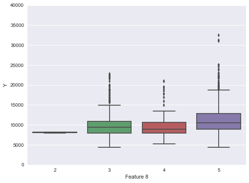

```python
#box plot
var = 'Feature 8'
data1 = pd.concat([data['Y'], data[var]], axis=1)
f, ax = plt.subplots(figsize=(8, 6))
fig = sns.boxplot(x=var, y="Y", data=data1)
fig.axis(ymin=0, ymax=40000);
plt.show()
```

## Relationship with Continuous features with Y

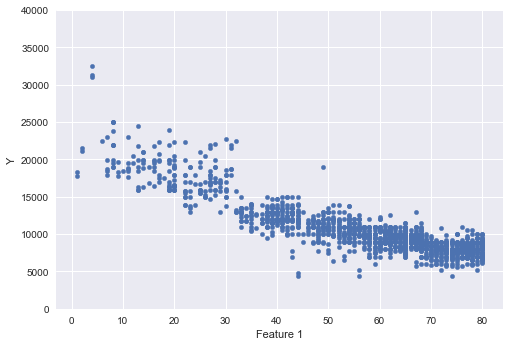

```python
#scatter plot Feature 1
var = 'Feature 1'
data1 = pd.concat([data['Y'], data[var]], axis=1)
data1.plot.scatter(x=var, y='Y', ylim=(0,40000));
plt.show()
```

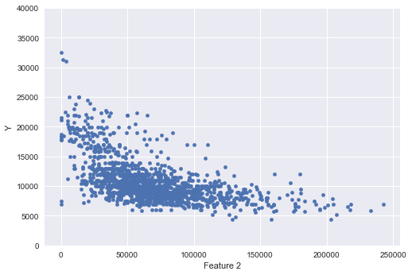

```python
#scatter plot Feature 2
var = 'Feature 2'
data1 = pd.concat([data['Y'], data[var]], axis=1)
data1.plot.scatter(x=var, y='Y', ylim=(0,40000));
plt.show()
```

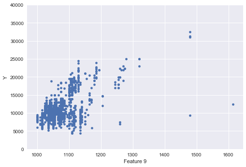

```python
#scatter plot Feature 9
var = 'Feature 9'
data1 = pd.concat([data['Y'], data[var]], axis=1)
data1.plot.scatter(x=var, y='Y', ylim=(0,40000));
plt.show()
```

Feature 1 shows strong linear relationship and feature 9 shows a bit of linear While feature 2 shows less linear relationship

# Model Inference

```python
import pandas as pd
import numpy as np
import seaborn as sns

import matplotlib.pyplot as plt
from scipy.stats import skew
from scipy.stats.stats import pearsonr
import xgboost as xgb
from sklearn.ensemble import RandomForestRegressor
from sklearn.model_selection import KFold, train_test_split, GridSearchCV
from sklearn.metrics import confusion_matrix, mean_squared_error , mean_absolute_error
from sklearn.model_selection import train_test_split
from sklearn.metrics import mean_squared_error, r2_score
from sklearn.model_selection import cross_val_score
from sklearn import linear_model

%config InlineBackend.figure_format = 'retina' #set 'png' here when working on notebook
%matplotlib inline
```

```python
def rmse_cv(model):
    rmse= np.sqrt(-cross_val_score(model, X_train, y_train, scoring="neg_mean_squared_error", cv = 5))
    return(rmse)
```

```python
#Formatting
df = data[['Y', 'Feature 1', 'Feature 2', 'Feature 4', 'Feature 5',
          'Feature 6', 'Feature 7', 'Feature 8', 'Feature 9']]
```

```python
df.dtypes
```

```
Y            int64
Feature 1    int64
Feature 2    int64
Feature 4    int64
Feature 5    int64
Feature 6    int64
Feature 7    int64
Feature 8    int64
Feature 9    int64
dtype: object
```

```python
# df['Feature 4'] = df['Feature 4'].astype(str)
df['Feature 5'] = df['Feature 5'].astype(str)
df['Feature 6'] = df['Feature 6'].astype(str)
# df['Feature 7'] = df['Feature 7'].astype(str)
df['Feature 8'] = df['Feature 8'].astype(str)
```

```python
df
```

|  | Y | Feature 1 | Feature 2 | Feature 4 | Feature 5 | Feature 6 | Feature 7 | Feature 8 | Feature 9 |
| --- | --- | --- | --- | --- | --- | --- | --- | --- | --- |
| 0 | 13500 | 23 | 46986 | 90 | 1 | 0 | 2000 | 3 | 1165 |
| 1 | 13750 | 23 | 72937 | 90 | 1 | 0 | 2000 | 3 | 1165 |
| 2 | 13950 | 24 | 41711 | 90 | 1 | 0 | 2000 | 3 | 1165 |
| 3 | 14950 | 26 | 48000 | 90 | 0 | 0 | 2000 | 3 | 1165 |
| 4 | 13750 | 30 | 38500 | 90 | 0 | 0 | 2000 | 3 | 1170 |
| 5 | 12950 | 32 | 61000 | 90 | 0 | 0 | 2000 | 3 | 1170 |
| 6 | 16900 | 27 | 94612 | 90 | 1 | 0 | 2000 | 3 | 1245 |
| 7 | 18600 | 30 | 75889 | 90 | 1 | 0 | 2000 | 3 | 1245 |
| 8 | 21500 | 27 | 19700 | 192 | 0 | 0 | 1800 | 3 | 1185 |
| 9 | 12950 | 23 | 71138 | 69 | 0 | 0 | 1900 | 3 | 1105 |
| 10 | 20950 | 25 | 31461 | 192 | 0 | 0 | 1800 | 3 | 1185 |
| 11 | 19950 | 22 | 43610 | 192 | 0 | 0 | 1800 | 3 | 1185 |
| 12 | 19600 | 25 | 32189 | 192 | 0 | 0 | 1800 | 3 | 1185 |
| 13 | 21500 | 31 | 23000 | 192 | 1 | 0 | 1800 | 3 | 1185 |
| 14 | 22500 | 32 | 34131 | 192 | 1 | 0 | 1800 | 3 | 1185 |
| 15 | 22000 | 28 | 18739 | 192 | 0 | 0 | 1800 | 3 | 1185 |
| 16 | 22750 | 30 | 34000 | 192 | 1 | 0 | 1800 | 3 | 1185 |
| 17 | 17950 | 24 | 21716 | 110 | 1 | 0 | 1600 | 3 | 1105 |
| 18 | 16750 | 24 | 25563 | 110 | 0 | 0 | 1600 | 3 | 1065 |
| 19 | 16950 | 30 | 64359 | 110 | 1 | 0 | 1600 | 3 | 1105 |
| 20 | 15950 | 30 | 67660 | 110 | 1 | 0 | 1600 | 3 | 1105 |
| 21 | 16950 | 29 | 43905 | 110 | 0 | 1 | 1600 | 3 | 1170 |
| 22 | 15950 | 28 | 56349 | 110 | 1 | 0 | 1600 | 3 | 1120 |
| 23 | 16950 | 28 | 32220 | 110 | 1 | 0 | 1600 | 3 | 1120 |
| 24 | 16250 | 29 | 25813 | 110 | 1 | 0 | 1600 | 3 | 1120 |
| 25 | 15950 | 25 | 28450 | 110 | 1 | 0 | 1600 | 3 | 1120 |
| 26 | 17495 | 27 | 34545 | 110 | 1 | 0 | 1600 | 3 | 1120 |
| 27 | 15750 | 29 | 41415 | 110 | 1 | 0 | 1600 | 3 | 1120 |
| 28 | 16950 | 28 | 44142 | 110 | 0 | 0 | 1600 | 3 | 1120 |
| 29 | 17950 | 30 | 11090 | 110 | 1 | 0 | 1600 | 3 | 1120 |
| ... | ... | ... | ... | ... | ... | ... | ... | ... | ... |
| 1406 | 8950 | 70 | 44850 | 110 | 1 | 0 | 1600 | 3 | 1050 |
| 1407 | 8250 | 69 | 44826 | 110 | 0 | 0 | 1600 | 5 | 1075 |
| 1408 | 9250 | 80 | 44444 | 110 | 1 | 0 | 1600 | 3 | 1050 |
| 1409 | 7900 | 75 | 43720 | 110 | 1 | 0 | 1600 | 5 | 1070 |
| 1410 | 8500 | 78 | 43622 | 86 | 1 | 0 | 1300 | 4 | 1000 |
| 1411 | 7950 | 76 | 43532 | 110 | 0 | 0 | 1600 | 5 | 1070 |
| 1412 | 9950 | 69 | 42800 | 110 | 1 | 0 | 1600 | 3 | 1050 |
| 1413 | 8750 | 74 | 42317 | 107 | 1 | 1 | 1600 | 5 | 1100 |
| 1414 | 7500 | 80 | 42186 | 110 | 1 | 0 | 1600 | 3 | 1050 |
| 1415 | 6950 | 72 | 42000 | 110 | 1 | 0 | 1600 | 3 | 1050 |
| 1416 | 8950 | 79 | 40093 | 110 | 0 | 0 | 1600 | 5 | 1114 |
| 1417 | 8750 | 79 | 39800 | 107 | 0 | 1 | 1600 | 3 | 1080 |
| 1418 | 7750 | 73 | 39168 | 86 | 0 | 0 | 1300 | 3 | 1015 |
| 1419 | 8450 | 75 | 38945 | 110 | 1 | 0 | 1600 | 3 | 1050 |
| 1420 | 8150 | 76 | 36537 | 110 | 0 | 1 | 1600 | 4 | 1075 |
| 1421 | 8500 | 78 | 36000 | 86 | 0 | 1 | 1300 | 3 | 1045 |
| 1422 | 7600 | 78 | 36000 | 110 | 1 | 0 | 1600 | 3 | 1050 |
| 1423 | 7950 | 80 | 35821 | 86 | 0 | 1 | 1300 | 3 | 1015 |
| 1424 | 7750 | 73 | 34717 | 86 | 0 | 0 | 1300 | 3 | 1015 |
| 1425 | 7950 | 80 | 34000 | 86 | 1 | 0 | 1300 | 4 | 1000 |
| 1426 | 9950 | 78 | 30964 | 110 | 0 | 1 | 1600 | 3 | 1080 |
| 1427 | 8950 | 71 | 29000 | 86 | 1 | 1 | 1300 | 3 | 1045 |
| 1428 | 8450 | 72 | 26000 | 86 | 0 | 0 | 1300 | 3 | 1015 |
| 1429 | 8950 | 78 | 24000 | 86 | 1 | 1 | 1300 | 5 | 1065 |
| 1430 | 8450 | 80 | 23000 | 86 | 0 | 0 | 1300 | 3 | 1015 |
| 1431 | 7500 | 69 | 20544 | 86 | 1 | 0 | 1300 | 3 | 1025 |
| 1432 | 10845 | 72 | 19000 | 86 | 0 | 0 | 1300 | 3 | 1015 |
| 1433 | 8500 | 71 | 17016 | 86 | 0 | 0 | 1300 | 3 | 1015 |
| 1434 | 7250 | 70 | 16916 | 86 | 1 | 0 | 1300 | 3 | 1015 |
| 1435 | 6950 | 76 | 1 | 110 | 0 | 0 | 1600 | 5 | 1114 |

1436 rows × 9 columns

```python
#log transform the target:
df["Y"] = np.log1p(df["Y"])

#log transform skewed numeric features:
numeric_feats = df.dtypes[df.dtypes != "object"].index

skewed_feats = df[numeric_feats].apply(lambda x: skew(x.dropna())) #compute skewness
skewed_feats = skewed_feats[skewed_feats > 0.75]
skewed_feats = skewed_feats.index

df[skewed_feats] = np.log1p(df[skewed_feats])
```

```
array([[<matplotlib.axes._subplots.AxesSubplot object at 0x000001E6B5A577F0>,
        <matplotlib.axes._subplots.AxesSubplot object at 0x000001E6B5B2B160>]], dtype=object)
```

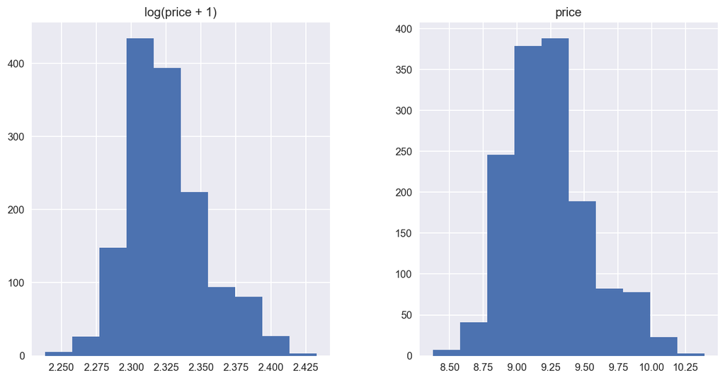

```python
matplotlib.rcParams['figure.figsize'] = (12.0, 6.0)
prices = pd.DataFrame({"price":df["Y"], "log(price + 1)":np.log1p(df["Y"])})
prices.hist()
```

```python
df = pd.get_dummies(df) # one hot encoding
```

```python
# rng = np.random.RandomState(31337)

print("Crayon: regression")
X, y = df.iloc[:,1:14], df.Y

X_train, X_test, y_train, y_test = train_test_split(X, y, test_size=0.80, random_state=42)

# X_train,y_train,X_test,y_test = train.iloc[:,1:26], train.avgRating,test.iloc[:,1:26], test.avgRating
# kf = KFold(n_splits=2, shuffle=True, random_state=rng)
```

```
Crayon: regression
```

## Linear Regression

Normality - When we talk about normality what we mean is that the data should look like a normal distribution. This is important because several statistic tests rely on this (e.g. t-statistics). In this exercise we'll just check univariate normality for 'Y' (which is a limited approach). Also the univariate normality doesn't ensure multivariate normality (which is what we would like to have), but it helps. Another detail to take into account is that in big samples (>200 observations) normality is not such an issue. However, if we solve normality, we avoid a lot of other problems (e.g. heteroscedacity) so that's the main reason why we are doing this analysis.

Homoscedasticity -Homoscedasticity refers to the 'assumption that dependent variable(s) exhibit equal levels of variance across the range of predictor variable(s)'. Homoscedasticity is desirable because we want the error term to be the same across all values of the independent variables.

Linearity- The most common way to assess linearity is to examine scatter plots and search for linear patterns. If patterns are not linear, it would be worthwhile to explore data transformations. However, most of the scatter plots we've seen appear to have linear relationships.

Absence of correlated errors - Correlated errors, like the definition suggests, happen when one error is correlated to another. For instance, if one positive error makes a negative error systematically, it means that there's a relationship between these variables. This occurs often in time series, where some patterns are time related. We'll also not get into this.

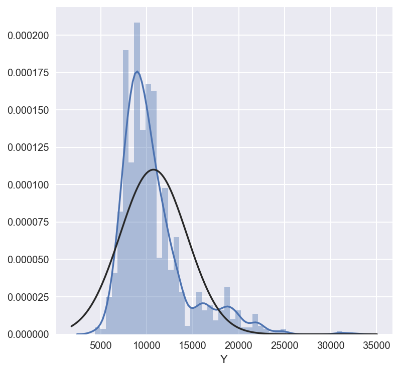

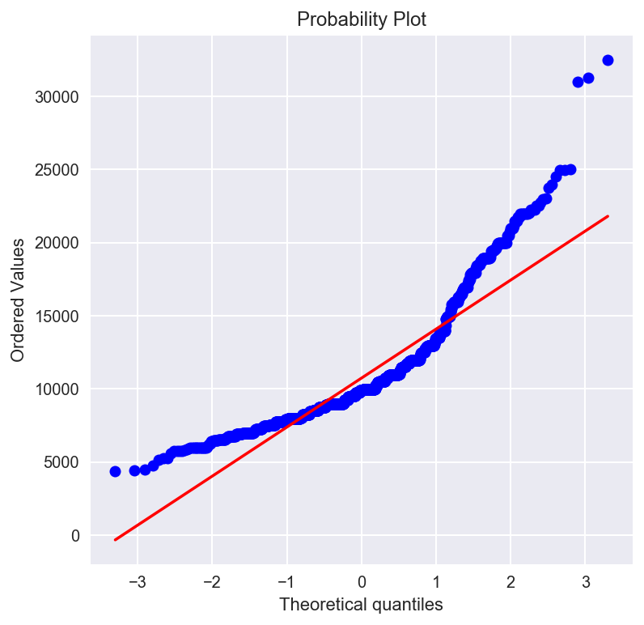

```python
## Pre Normalization / transformation

from scipy.stats import norm
from scipy import stats
#histogram and normal probability plot
sns.distplot(data['Y'], fit=norm);
fig = plt.figure()
res = stats.probplot(data['Y'], plot=plt)
```

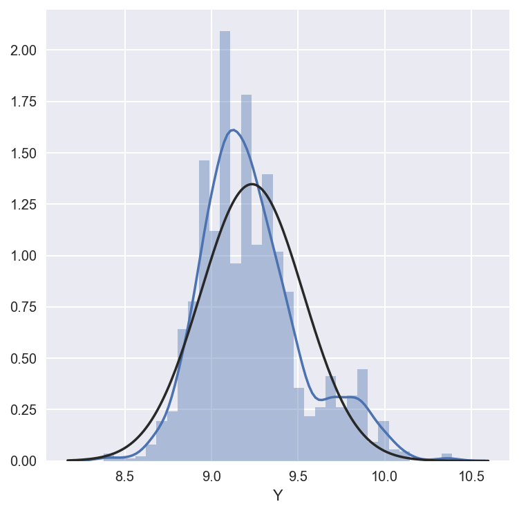

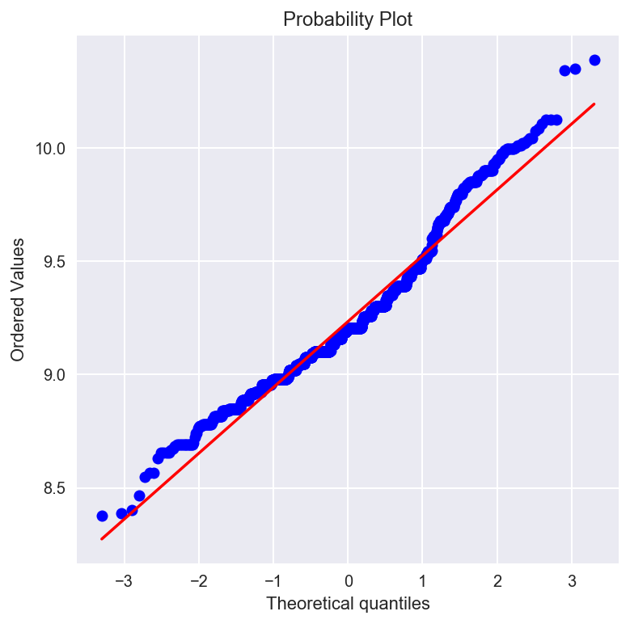

```python
## Post Normalization / transformation
from scipy.stats import norm
from scipy import stats
#histogram and normal probability plot
sns.distplot(df['Y'], fit=norm);
fig = plt.figure()
res = stats.probplot(df['Y'], plot=plt)
```

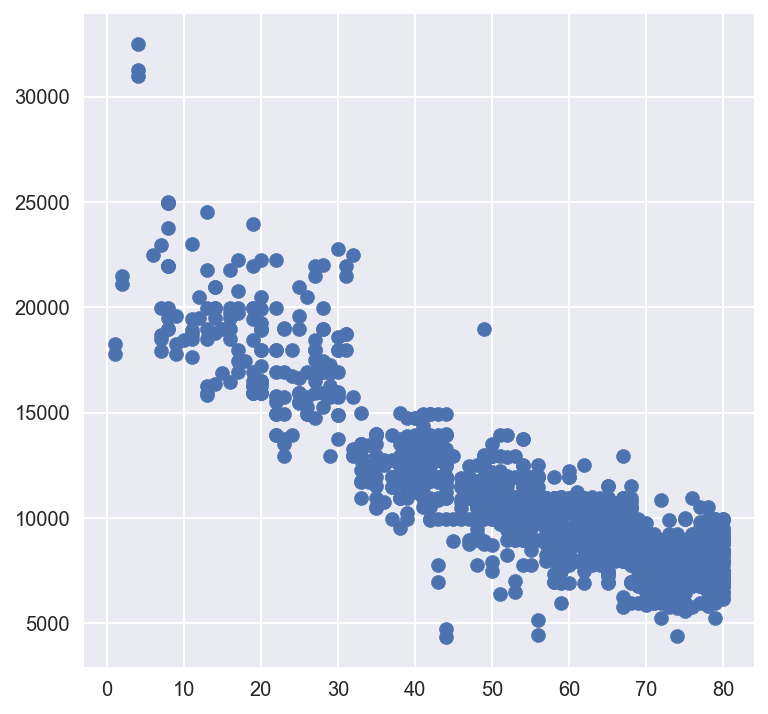

```python
# homoscedasticity Test
# Pre transformation
#scatter plot
plt.scatter(data['Feature 1'], data['Y']);
```

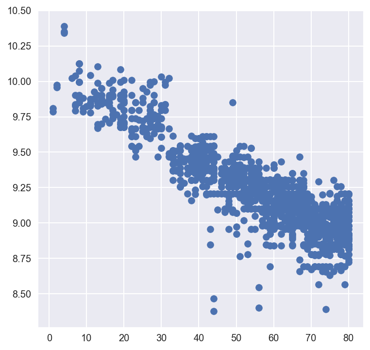

```python
# homoscedasticity Test
# Post transformation
#scatter plot
plt.scatter(df['Feature 1'], df['Y']); # Linear relationship
```

```python
# Create linear regression object
linreg = linear_model.LinearRegression()

# Train the model using the training sets
linreg.fit(X_train, y_train)
```

```
LinearRegression(copy_X=True, fit_intercept=True, n_jobs=1, normalize=False)
```

```python
# The coefficient of determination: 1 is perfect prediction
print('Coefficient of determination: %.2f '
      % r2_score(y_test, linreg.predict(X_test)))

# The coefficients
print('\n Coefficients: \n', linreg.coef_)
#Intercept
print('\n Intercept: \n', linreg.intercept_)
```

```
Coefficient of determination: 0.72

 Coefficients:
 [ -1.04261592e-02  -1.06743167e-01   3.06970449e-01  -4.40802817e-05
   1.05987633e+00  -9.08007172e-03   9.08007172e-03  -2.13393984e-02
   2.13393984e-02   0.00000000e+00  -1.08928030e-03  -1.60498809e-02
   1.71391612e-02]

 Intercept:
 2.25043970938
```

```python
rmse_cv(linreg).mean()
```

```
0.13408265050372081
```

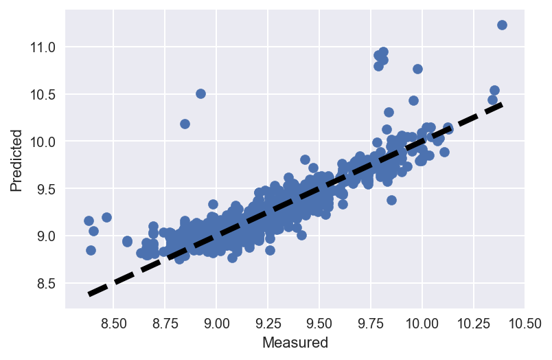

```python
predictions1 = linreg.predict(X_test)
actuals1 = y_test

fig, ax = plt.subplots()
ax.scatter(actuals1, predictions1)
ax.plot([actuals1.min(), actuals1.max()], [actuals1.min(), actuals1.max()], 'k--', lw=4)
ax.set_xlabel('Measured')
ax.set_ylabel('Predicted')
plt.show()
```

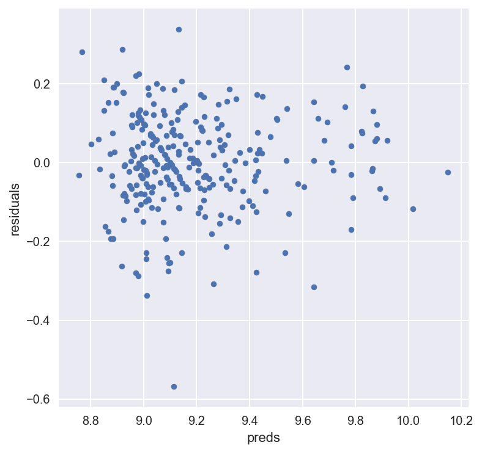

```python
#let's look at the residuals as well:
matplotlib.rcParams['figure.figsize'] = (6.0, 6.0)

preds = pd.DataFrame({"preds":linreg.predict(X_train), "true":y_train})
preds["residuals"] = preds["true"] - preds["preds"]
preds.plot(x = "preds", y = "residuals",kind = "scatter")
```

```python
# coef = pd.Series(regr.coef_, index = X_train.columns)
```

```python
# imp_coef = pd.concat([coef.sort_values().head(10),
#                      coef.sort_values().tail(10)])
# matplotlib.rcParams['figure.figsize'] = (8.0, 10.0)
# imp_coef.plot(kind = "barh")
# plt.title("Coefficients in the Linreg Model")


# #let's look at the residuals as well:
# matplotlib.rcParams['figure.figsize'] = (6.0, 6.0)

# preds = pd.DataFrame({"preds":regr.predict(X_train), "true":y_train})
# preds["residuals"] = preds["true"] - preds["preds"]
# preds.plot(x = "preds", y = "residuals",kind = "scatter")
```

## Ridge Regression ( Regularized )

```python
# using the default CV
alphas = [0.1, 1, 10, 100, 1e3, 1e4, 2e4, 5e4, 8e4, 1e5, 1e6, 1e7, 1e8]
reg = linear_model.RidgeCV(alphas=alphas, store_cv_values=True)
reg.fit(X_train, y_train)
```

```
RidgeCV(alphas=[0.1, 1, 10, 100, 1000.0, 10000.0, 20000.0, 50000.0, 80000.0, 100000.0, 1000000.0, 10000000.0, 100000000.0],
    cv=None, fit_intercept=True, gcv_mode=None, normalize=False,
    scoring=None, store_cv_values=True)
```

[figure not shown]

```python
model_ridge = Ridge()
cv_ridge = [rmse_cv(Ridge(alpha = alpha)).mean()
            for alpha in alphas]
cv_ridge = pd.Series(cv_ridge, index = alphas)
cv_ridge.plot(title = "Validation - Just Do It")
plt.xlabel("alpha")
plt.ylabel("rmse")
```

```python
# generate the prediction using the best model
alpha = reg.alpha_
reg = linear_model.Ridge(alpha=alpha)
#reg.fit(train_x, train_y, sample_weight=sample_weight)
reg.fit(X_train, y_train)
```

[output not shown]

```python
# The coefficient of determination: 1 is perfect prediction
print('Coefficient of determination: %.2f '
      % r2_score(y_test, reg.predict(X_test)))

# The coefficients
print('\n Coefficients: \n', reg.coef_)
#Intercept
print('\n Intercept: \n', reg.intercept_)
```

```
Coefficient of determination: 0.72

 Coefficients:
 [ -1.06492929e-02  -1.08886811e-01   2.99240164e-01   1.39322274e-06
   7.56608374e-01  -8.83496107e-03   8.83496107e-03  -2.41114414e-02
   2.41114414e-02   0.00000000e+00  -1.27383558e-03  -2.10906458e-02
   2.23644813e-02]

 Intercept:
 4.36840627201
```

```python
rmse_cv(reg).mean()
```

```
0.12889381893853022
```

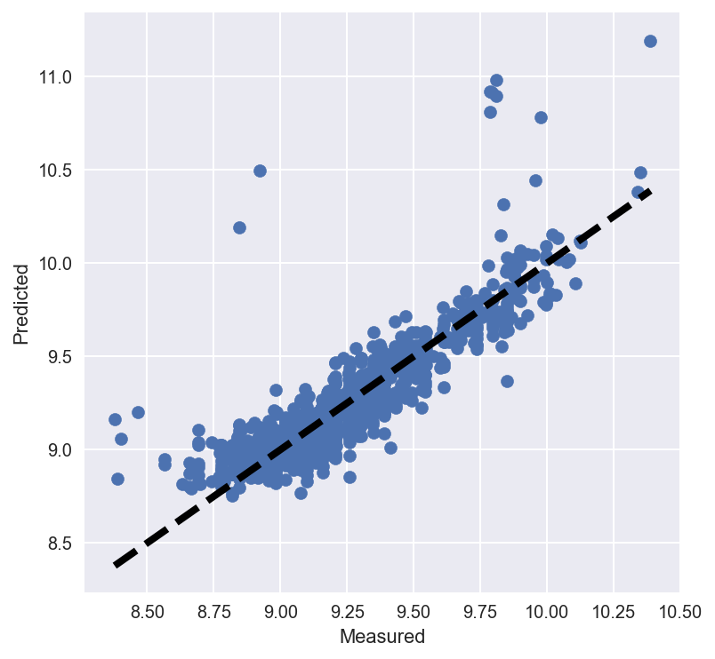

```python
predictions1 = reg.predict(X_test)
actuals1 = y_test

fig, ax = plt.subplots()
ax.scatter(actuals1, predictions1)
ax.plot([actuals1.min(), actuals1.max()], [actuals1.min(), actuals1.max()], 'k--', lw=4)
ax.set_xlabel('Measured')
ax.set_ylabel('Predicted')
plt.show()
```

```python
from sklearn.linear_model import Ridge, RidgeCV, ElasticNet, LassoCV, LassoLarsCV
from sklearn.model_selection import cross_val_score
```

## Lasso Regression - ( Regularized )

```python
model_lasso_tr = LassoCV(alphas = [1, 0.1, 0.001, 0.0005,0.0007]).fit(X_train, y_train)
```

```python
# The coefficient of determination: 1 is perfect prediction
print('Coefficient of determination: %.2f '
      % r2_score(y_test, model_lasso_tr.predict(X_test)))

# The coefficients
print('\n Coefficients: \n', model_lasso_tr.coef_)
#Intercept
print('\n Intercept: \n', model_lasso_tr.intercept_)
```

```
Coefficient of determination: 0.71

 Coefficients:
 [ -1.08774443e-02  -1.10195852e-01   2.81313206e-01   3.53225524e-05
   5.13034196e-01  -1.53364870e-02   7.91999758e-18  -4.09639529e-02
   2.81779092e-16   0.00000000e+00   0.00000000e+00  -1.82270633e-02
   2.72129807e-02]

 Intercept:
 6.14733316341
```

```python
## train
predictions = model_lasso_tr.predict(X_train)
actuals = y_train
# print(mean_squared_error(actuals, predictions))
print(mean_absolute_error(actuals, predictions))

## Test
predictions = model_lasso_tr.predict(X_test)
actuals = y_test
# print(mean_squared_error(actuals, predictions))
print(mean_absolute_error(actuals, predictions))
```

```
0.0936410643724
0.100032833847
```

```python
rmse_cv(model_lasso_tr).mean()
```

```
0.13008970959357752
```

```python
coef = pd.Series(model_lasso_tr.coef_, index = X_train.columns)
```

```python
print("Lasso picked " + str(sum(coef != 0)) + " variables and eliminated the other " +  str(sum(coef == 0)) + " variables")
```

```
Lasso picked 11 variables and eliminated the other 2 variables
```

```python
imp_coef = pd.concat([coef.sort_values().head(10),
                     coef.sort_values().tail(10)])
```

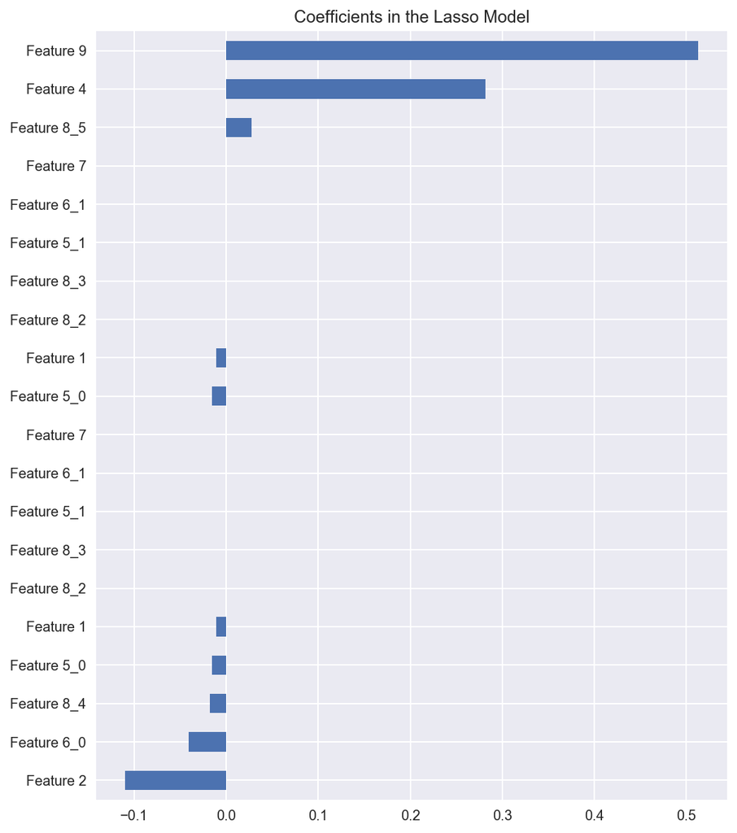

```python
matplotlib.rcParams['figure.figsize'] = (8.0, 10.0)
imp_coef.plot(kind = "barh")
plt.title("Coefficients in the Lasso Model")
```

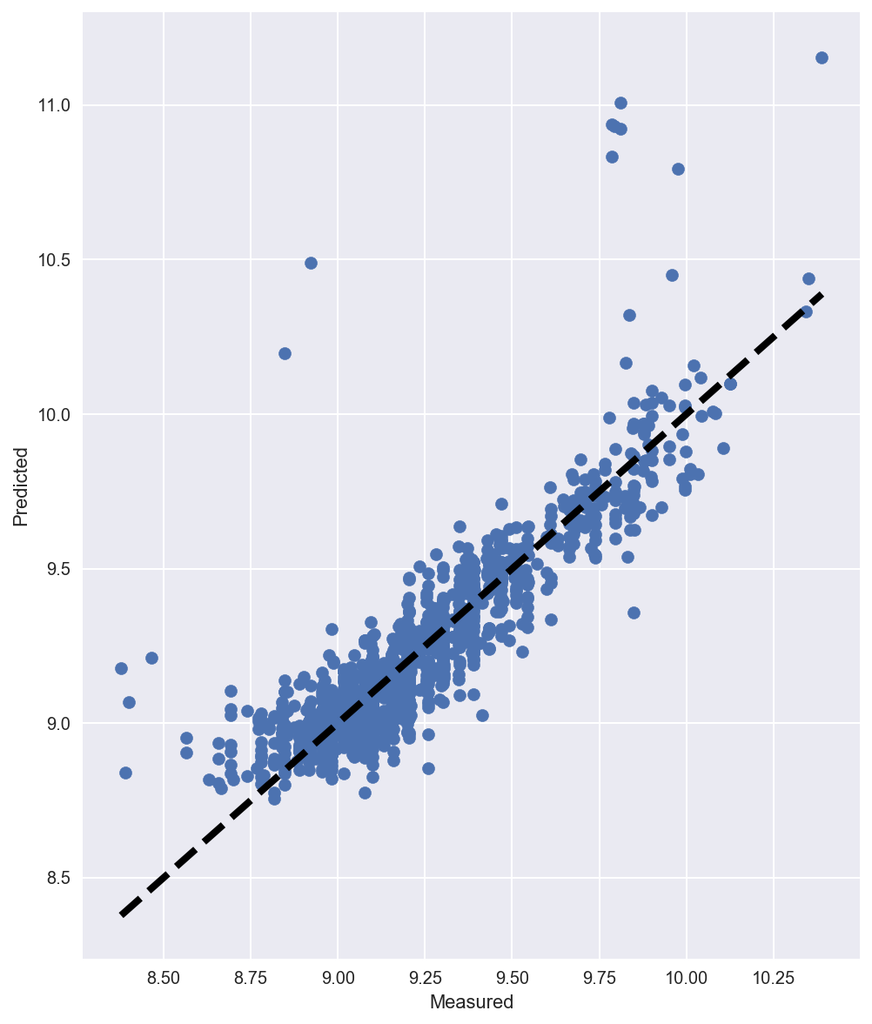

```python
predictions1 = model_lasso_tr.predict(X_test)
actuals1 = y_test

fig, ax = plt.subplots()
ax.scatter(actuals1, predictions1)
ax.plot([actuals1.min(), actuals1.max()], [actuals1.min(), actuals1.max()], 'k--', lw=4)
ax.set_xlabel('Measured')
ax.set_ylabel('Predicted')
plt.show()
```

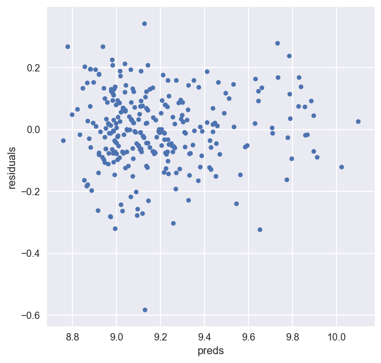

```python
#let's look at the residuals as well:
matplotlib.rcParams['figure.figsize'] = (6.0, 6.0)

preds = pd.DataFrame({"preds":model_lasso_tr.predict(X_train), "true":y_train})
preds["residuals"] = preds["true"] - preds["preds"]
preds.plot(x = "preds", y = "residuals",kind = "scatter")
```